# 第7讲笔记

定量数据分析

# 引言

- 上次我们学习了如何检验观察到的差异是否由抽样误差造成。
- 我们检验了男女平均工资之间的差异。
- 今天我们将学习如何检验两个以上类别之间的差异。
- 看看平均工资是否随教育水平而变化（教育水平由个人获得的最高学历或资格来衡量）。
- 为了我们大家的利益，希望答案是肯定的！

# 最高学历／资格水平

| 最高学历／资格 | 观测数 | 平均工资（英镑） | 标准差 |
| --- | --- | --- | --- |
| 学位或同等资格 | 3535 | 25.02 | 12.65 |
| 高等教育 | 565 | 19.63 | 9.88 |
| A Level或同等资格 | 1604 | 17.33 | 8.86 |
| GCSE A*–C或同等资格 | 1102 | 16.16 | 8.29 |
| 其他资格 | 331 | 15.63 | 8.55 |
| 无资格证书 | 210 | 13.53 | 5.39 |

# 最高学历／资格水平

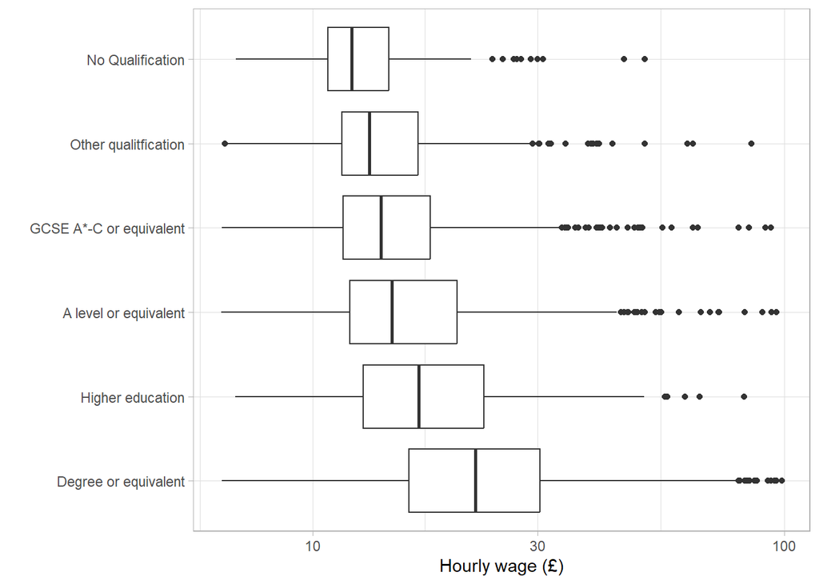

# 教育

- 从图中可以看出，工资中位数随教育水平而变化。
- 然而，不同组别之间仍有大量重叠。
- 如果重新抽取一个样本，这些差异还能重复出现吗？

# 我们的假设是什么？

- 我们认为教育与工资有关。
  $$H_0: \mu_{degree} = \mu_{HE} = \mu_{A level} =
  \mu_{GCSE} = \mu_{Other} = \mu_{None}$$
  $$H_A: \mu_{degree} \neq \mu_{HE} \neq \mu_{A
  level} \neq \mu_{GCSE} \neq \mu_{Other} \neq \mu_{None}$$

# 线性模型

- 我们可以利用线性模型框架写出一个方程。
- 定义一组虚拟变量，在以下情形中取值：
  - 如果所讨论的资格是该人拥有的最高资格，则取1。
  - 否则取0。

# 回归方程

$$\textrm{Wage}_i = \beta_0 + \beta_1
\cdot \textrm{HE}_i + \beta_2 \cdot \textrm{A level}_i + \beta_3 \cdot
\textrm{GCSE}_i + \\
\beta_4 \cdot \textrm{Other}_i + \beta_5 \cdot
\textrm{None}_i$$

# 模型参数

- $\beta_0$ will be the average wage of a person with a degree
- $\beta_1$ is the difference between the average wage of a person with a degree and a person with only some higher education
- $\beta_2$ is the difference between the average wage of a person with a degree and a person with A levels
- $\beta_3$ is the difference between the average wage of a person with a degree and a person with GCSEs
- $\beta_4$ is the difference between the average wage of a person with a degree and a person with some other qualification
- $\beta_5$ is the difference between the average wage of a person with a degree and a person with no qualifications

# 线性回归模型

```r
lm(HOURPAY ~ HIQUL22D, data = lfs) %>% summary()
```

# 线性回归模型

```
##
## Call:
## lm(formula = HOURPAY ~ HIQUL22D, data = lfs)
##
## Residuals:
##     Min      1Q  Median      3Q     Max
## -18.595  -6.305  -2.448   3.576  78.822
##
## Coefficients:
##                                 Estimate Std. Error t value Pr(>|t|)
## (Intercept)                      25.0155     0.1812  138.06   <2e-16 ***
## HIQUL22DHigher education         -5.3873     0.4881  -11.04   <2e-16 ***
## HIQUL22DA level or equivalent    -7.6878     0.3243  -23.70   <2e-16 ***
## HIQUL22DGCSE A*-C or equivalent  -8.8511     0.3717  -23.81   <2e-16 ***
## HIQUL22DOther qualitfication     -9.3824     0.6192  -15.15   <2e-16 ***
## HIQUL22DNo Qualification        -11.4876     0.7652  -15.01   <2e-16 ***
## ---
## Signif. codes:  0 '***' 0.001 '**' 0.01 '*' 0.05 '.' 0.1 ' ' 1
##
## Residual standard error: 10.77 on 7341 degrees of freedom
## Multiple R-squared:  0.1293, Adjusted R-squared:  0.1287
## F-statistic: 218.1 on 5 and 7341 DF,  p-value: < 2.2e-16
```

# 结果解释

- 这里我们得到了较强的结果。
- 所有低于学位水平的教育类别，其平均工资都更低。
- 所有差异都具有统计显著性。
- 在本例中，有足够证据拒绝之前设定的原假设。
- 但并非总会如此。
- 有时各参数单独来看都不显著，但联合起来却具有显著性。

# 变异

- 数据的变异可以从两个维度理解：
  1. 组内变异（同一教育类别内）。
  2. 组间变异（不同教育类别之间）。
- 我们需要回答的是：组间差异是否显著大于人与人之间的差异？

# 将这些概念形式化

- 需要将刚才讨论的变异概念写成正式的统计量：
  1. 总变异：总平方和（SST）。
  2. 组间变异：组间平方和（SSA）。
  3. 组内变异：组内平方和（SSW）。

# 总变异

总平方和可以定义为：

$$SST =
\sum_{j=1}^c{\sum_{i=1}^{n_j}{(X_{ij}-\bar{\bar{X}})^2}}$$
where

- $\bar{\bar{X}} = \frac{\sum_{j=1}^c{\sum_{i=1}^{n_j}{X_{ij}}}}{n} =$ Grand Mean
- $X_{ij}$ is the $i$th value in group $j$
- $n_j$ is the number of values in group $j$
- $n$ is the total number of values across all groups
- $c$ is the number of groups

# 组间变异

组间变异定义为：

$$SSA=\sum_{j=1}^c{n_j(\bar{X}_j -
\bar{\bar{X}})^2}$$

其中：

- $c$ is the number of groups
- $n_j$ is the number of values in group $j$
- $\bar{X}_j$ is the sample mean of group $j$
- $\bar{\bar{X}}$ is the grand mean

# 组内变异

组内变异定义为：

$$SSW =
\sum_{j=1}^c{\sum_{i=1}^{n_j}{(X_{ij}-\bar{X}_j)^2}}$$
where

- $X_{ij}$ is the $i$th value in group $j$
- $\bar{X}_j$ is the sample mean of group $j$

# 均方

- 我们可以将这三个平方和（SS）分别除以其自由度（d.o.f.），得到方差或均方。
  1. 组间平方和比较$c$个组，贡献$c-1$个自由度。
  2. 由于每个$c$组都贡献$n_j-1$个自由度，因此组内平方和对应$n-c$个自由度。
  3. 总变异对应$n-1$个自由度，因为共有$n$个观测值和$1$个总体样本均值。

# 均方误差

组间均方：

$$MSA = \frac{SSA}{c-1}$$
The Mean Square Within:

$$MSW = \frac{SSW}{n-c}$$
The Mean Square Total:

$$MST = \frac{SST}{n-1}$$

# 检验

- 开展检验需要：
  1. 陈述原假设与备择假设。
  2. 定义检验统计量。
  3. 选择显著性水平。

# 假设

$$H_0: \mu_1 = \mu_2 = ... =
\mu_c$$
$$H_A: \mu_1 \neq \mu_2 \neq
... \neq \mu_c$$

- 原假设认为各组均值之间没有统计学上的差异。
- 备择假设认为并非所有组的均值都相等。
- 可能只有一个组的均值与其他组存在显著差异。
- 这个方法本身并不告诉我们哪些组的均值不同。

# 检验统计量

- 我们使用F检验来检验原假设。
- 它利用F分布。

$$F=\frac{MSA}{MSW}$$

- $F$ is our test statistic with $c-1$ degrees of freedom on the numerator and $n-c$ degrees of freedom on the denominator
- MSA表示组间均方。
- MSW表示组内均方。

# F检验

- 幸运的是，我们不必手工完成全部计算。
- 可以使用R中的方差分析（ANOVA）函数。

```r
aov(HOURPAY ~ HIQUL22D, data = lfs) %>% summary()
```

```
##               Df Sum Sq Mean Sq F value Pr(>F)
## HIQUL22D       5 126542   25308   218.1 <2e-16 ***
## Residuals   7341 851935     116
## ---
## Signif. codes:  0 '***' 0.001 '**' 0.01 '*' 0.05 '.' 0.1 ' ' 1
```

# 结果解释

- 可以看到，R提供了部分计算过程的信息。
- 它告诉我们最终的F值。
- 更关键的是，我们还得到了p值。
- 它非常小，因此可以有把握地拒绝原假设。
- 看来平均工资确实随教育水平变化。

# 补充信息

- 请注意，Sum Sq列显示平方和。
- 它是衡量数据变异的指标。
- 这里将其拆分为两部分：
  1. 可由分类变量（HIQUL22D）解释的变异。
  2. 尚未解释的变异（残差Residuals）。
- 由此可以计算教育变量解释了多少变异。
- 用HIQUL22D对应的平方和除以总平方和。

$$\frac{126542}{126542 + 851935} =
0.129325$$

# 结果解释

- 计算结果为0.129325。
- 这说明教育水平可以解释工资差异中约12.93%的变异。
- 了解这些之后，让我们回到本讲开始时的线性模型。

# 原来它一直都在那里

```
Call:
lm(formula = HOURPAY ~ HIQUL22D, data = lfs)

Residuals:
    Min      1Q  Median      3Q     Max
-18.595  -6.305  -2.448   3.576  78.822

Coefficients:
                                Estimate Std. Error t value Pr(>|t|)
(Intercept)                      25.0155     0.1812  138.06   <2e-16 ***
HIQUL22DHigher education         -5.3873     0.4881  -11.04   <2e-16 ***
HIQUL22DA level or equivalent    -7.6878     0.3243  -23.70   <2e-16 ***
HIQUL22DGCSE A*-C or equivalent  -8.8511     0.3717  -23.81   <2e-16 ***
HIQUL22DOther qualitfication     -9.3824     0.6192  -15.15   <2e-16 ***
HIQUL22DNo Qualification        -11.4876     0.7652  -15.01   <2e-16 ***
---
Signif. codes:  0 '***' 0.001 '**' 0.01 '*' 0.05 '.' 0.1 ' ' 1

Residual standard error: 10.77 on 7341 degrees of freedom
Multiple R-squared:  0.1293,    Adjusted R-squared:  0.1287
F-statistic: 218.1 on 5 and 7341 DF,  p-value: < 2.2e-16
```

# 线性模型

- 现在我们又看到了线性模型的一些强大之处。
- 模型的一个假设是因变量属于区间尺度或比率尺度。
- 我们已经看到，分类变量可以作为自变量进入模型。
- 有序变量也采用相同的方式，但模型不会自动利用其顺序信息。
- 自变量也可以是区间尺度或比率尺度的连续变量。
- 假设我们想研究年龄与收入。

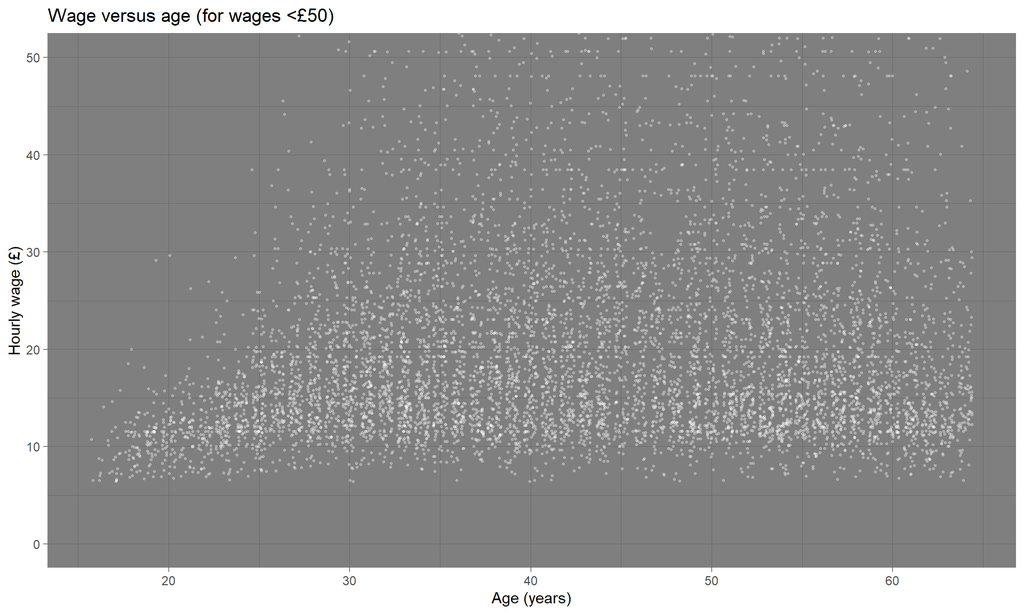

# 衡量变量关系

- 将数据可视化是理解两个变量之间关系的重要步骤。
- 将变量间的关系量化也很有用。
- 如果要检验统计显著性，也必须进行量化。
- 有几种可行的方法。

# 方差

- 我们已经接触过衡量单个变量变异的方差。
- 也可以考察两个变量如何共同变化。
- 回忆一下，样本方差写作：

$$S_x^2 = \frac{\sum_i^n
(x_i-\bar{x})^2}{n-1}$$
- The sample covariance is given by:

$$\textrm{cov}(X,Y)=\sum_{i=1}^N{\frac{(x_i-\bar{x})(y_i-\bar{y})}{n-1}}$$

# 协方差

- 如果$x$高于其均值时$y$也高于其均值，那么协方差为正。
- 如果$x$低于其均值时$y$高于其均值，那么协方差为负。
- 如果$x$的变化无法告诉我们$y$的变化情况，那么协方差为零。
- 协方差的单位较难解释，因为它依赖$x$和$y$各自的单位。
- 标准做法是通过两个变量各自的离散程度对其进行标准化。
- 这得到所谓的皮尔逊积差相关系数（Pearson product-moment correlation coefficient），取值范围在−1至1之间。

$$r= \frac{\sum{(x-\bar{x})(y-\bar{y}})}
{\sqrt{\sum{(x-\bar{x})^2} \sum{(y-\bar{y})^2}}}$$

# 如何解释r的绝对值

| 范围 | 相关强度 |
| --- | --- |
| 0 | 无相关关系 |
| 0-0.2 | 极弱、可忽略的相关关系 |
| 0.2-0.4 | 弱相关、低相关性 |
| 0.4-0.7 | 中等相关 |
| 0.7-0.9 | 强相关、高度相关 |
| 0.9-1 | 非常强的相关关系 |
| 1 | 完全相关 |

# 在R中计算相关系数

- 如果只需要相关系数，可以使用cor()函数。

```r
cor(lfs$HOURPAY, lfs$AGE)
```

```
## [1] 0.1375462
```

# 检验统计显著性

- 可以使用cor.test()函数检验相关系数的统计显著性。

```r
cor.test(lfs$HOURPAY, lfs$AGE)
```

```
##
##  Pearson's product-moment correlation
##
## data:  lfs$HOURPAY and lfs$AGE
## t = 11.901, df = 7345, p-value < 2.2e-16
## alternative hypothesis: true correlation is not equal to 0
## 95 percent confidence interval:
##  0.1150412 0.1599101
## sample estimates:
##       cor
## 0.1375462
```

# 检验统计显著性

- 也可以使用公式写法得到相同的结果。

```r
cor.test(~ HOURPAY + AGE, data=lfs)
```

```
##
##  Pearson's product-moment correlation
##
## data:  HOURPAY and AGE
## t = 11.901, df = 7345, p-value < 2.2e-16
## alternative hypothesis: true correlation is not equal to 0
## 95 percent confidence interval:
##  0.1150412 0.1599101
## sample estimates:
##       cor
## 0.1375462
```

# 线性模型

```r
lm(HOURPAY ~ AGE, data=lfs) %>% summary()
```

```
##
## Call:
## lm(formula = HOURPAY ~ AGE, data = lfs)
##
## Residuals:
##     Min      1Q  Median      3Q     Max
## -17.155  -7.615  -3.334   4.221  76.885
##
## Coefficients:
##             Estimate Std. Error t value Pr(>|t|)
## (Intercept) 15.18591    0.49378   30.75   <2e-16 ***
## AGE          0.13233    0.01112   11.90   <2e-16 ***
## ---
## Signif. codes:  0 '***' 0.001 '**' 0.01 '*' 0.05 '.' 0.1 ' ' 1
##
## Residual standard error: 11.43 on 7345 degrees of freedom
## Multiple R-squared:  0.01892,    Adjusted R-squared:  0.01879
## F-statistic: 141.6 on 1 and 7345 DF,  p-value: < 2.2e-16
```

# 线性模型

- 这里不能直接看到相关系数，但相关信息就在输出中。
- 将$R^2$开平方，就能得到相关系数的绝对值（其符号还需根据关系方向判断）。
- 在本例中，Estimate（估计系数）恰好也接近相关系数。
- 这只是巧合，尽管两项指标确实有关。
- 首先来看它从何而来。

# 猜测某个人的工资

- 如果我从总体中随机抽取一个人，让你猜测其工资，那么最好的猜测就是平均工资。

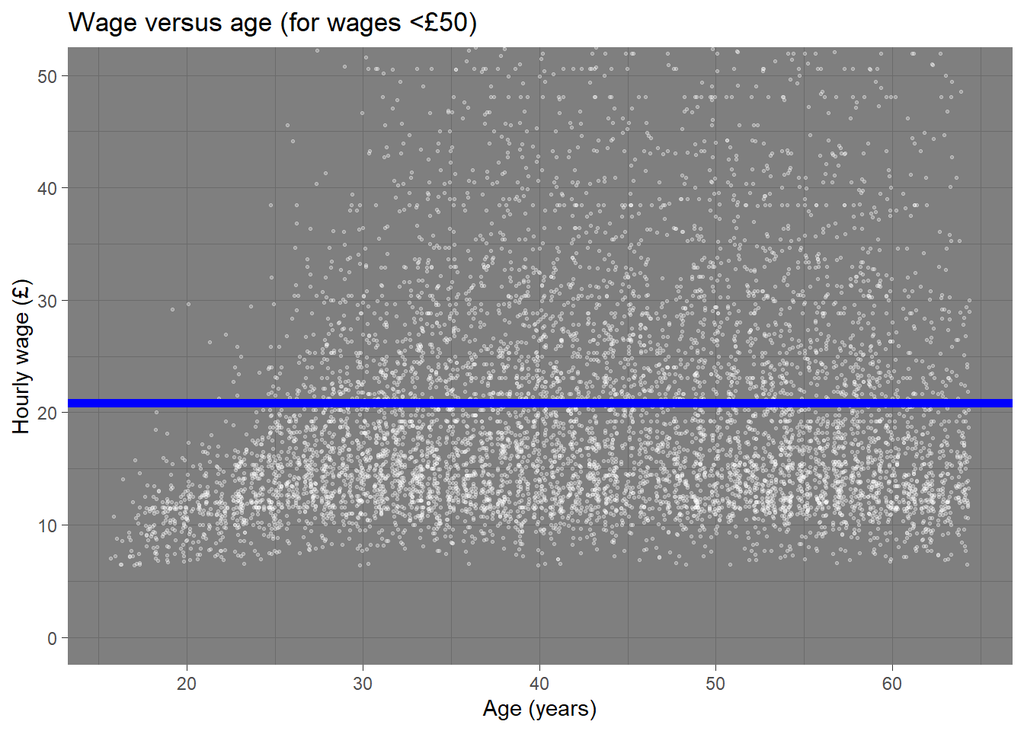

# 更好的预测

- 可以看到，年轻人的工资较低。
- 如果知道一个人的年龄，就可以更好地预测工资。
- 目前我们的预测方程为$\textrm{HOURPAY}_i = \beta_0$。
- 在方程中加入年龄：$\textrm{HOURPAY}_i = \beta_0 + \beta_1\cdot\textrm{AGE}$。
- 但这还不完全正确，因为找不到一组$\beta_0$和$\beta_1$能完美预测所有人的工资。
- 因此再加上一项表示预测误差：$\textrm{HOURPAY}_i = \beta_0 + \beta_1\cdot\textrm{AGE} + \varepsilon_i$。

# 选择参数

- 任务是选择能够优化预测的$\beta_0$和$\beta_1$取值。
- $\varepsilon$这一项代表预测误差，即残差。
- 我们希望让误差尽可能小。
- 一种衡量误差的方法是将残差平方后求和，即$\textrm{SSR} = \sum\varepsilon_i^2$。
- 然后选择使其最小的参数值。
- 可以通过数值方法解决问题。
- 也可以使用微积分。

# 求解所需方程

$$\frac{\partial}{\partial \hat{\beta_0}}
\sum_{i=1}^{n}(y_i - \hat{\beta_0} - \hat{\beta_1}x_i)^2 = -2
\sum{(y_i-\hat{\beta_0}-\hat{\beta_1}x_i)}$$

$$\frac{\partial}{\partial \hat{\beta_1}}
\sum_{i=1}^{n}(y_i - \hat{\beta_0} - \hat{\beta_1}x_i)^2 = -2
\sum{x_i(y_i-\hat{\beta_0}-\hat{\beta_1}x_i)}$$

# 解答

$$\hat{\beta_1}=\frac{\frac{1}{n}\sum_{i=1}^{n}x_i
y_i - \bar{x}\bar{y}}{\frac{1}{n}\sum_{i=1}^{n}
x_i^2-\bar{x}^2}$$

$$\hat{\beta_0}=\bar{y}-\hat{\beta_1}\bar{x}$$

# 线性模型

- 我们已经见过这些参数的求解结果。
- $\beta_0$ is the intercept from the linear model
- $\beta_1$ is the coefficient attached to age
- 可以用图形呈现其效果。

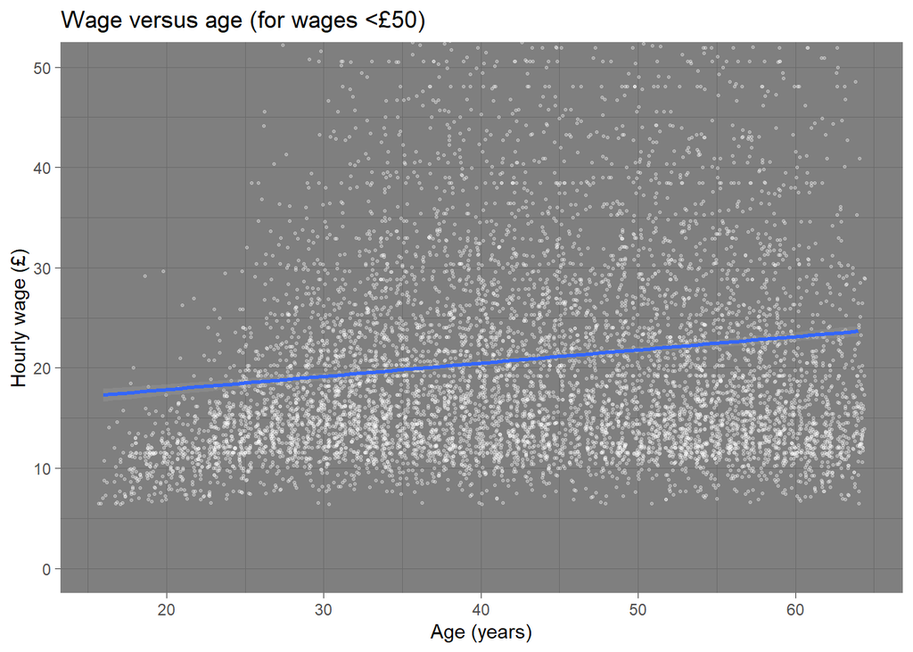

# 线性模型

```r
lm(HOURPAY ~ AGE, data=lfs) %>% summary()
```

```
##
## Call:
## lm(formula = HOURPAY ~ AGE, data = lfs)
##
## Residuals:
##     Min      1Q  Median      3Q     Max
## -17.155  -7.615  -3.334   4.221  76.885
##
## Coefficients:
##             Estimate Std. Error t value Pr(>|t|)
## (Intercept) 15.18591    0.49378   30.75   <2e-16 ***
## AGE          0.13233    0.01112   11.90   <2e-16 ***
## ---
## Signif. codes:  0 '***' 0.001 '**' 0.01 '*' 0.05 '.' 0.1 ' ' 1
##
## Residual standard error: 11.43 on 7345 degrees of freedom
## Multiple R-squared:  0.01892,    Adjusted R-squared:  0.01879
## F-statistic: 141.6 on 1 and 7345 DF,  p-value: < 2.2e-16
```

# 结果解释

- 截距代表年龄为零的人所对应的工资。
- 这并不是有用的解释。
- 在线性模型中，我们通常不会过分解读截距。
- 年龄的回归系数告诉我们年龄与工资之间的关联。
- 年龄每增加一岁，工资平均会高出0.13英镑。
- 这种关联具有统计显著性。
- 年龄变异能够解释工资变异中的1.9%。

# 相关与因果

相关不等于因果。

# 因与果的错误归因（Cum hoc ergo propter hoc）

- 这是一种著名的逻辑谬误。
- 使用这些方法，我们所展示的只是相关关系。
- 写作此类分析时必须谨慎。
- 不要写成“证明了”某个结论。
- 不要轻易说某事“导致”另一件事。
- 应该说某个变量与另一个变量“存在关联”。

# 总结

- 我们又看到了线性模型的一些强大之处。
- 它可以借助类别型、有序型以及连续（区间／比率尺度）自变量来衡量变量关联。
- 它还可以检验统计显著性。
- 后面还有更多精彩内容。